# Project_Data_Analysis

## Hopskin

```r
library(clustertend)
# Compute Hopkins statistic for the iris dataset
set.seed(1)
hopkins(df.scaled, n = nrow(df.scaled)-1)
```

```
## $H
## [1] 0.1872551
```

```r
# Compute Hopkins statistic for a random dataset
set.seed(1)
hopkins(scaled.random_seed, n = nrow(scaled.random_seed)-1)
```

```
## $H
## [1] 0.5003455
```

## VAT alghoritm

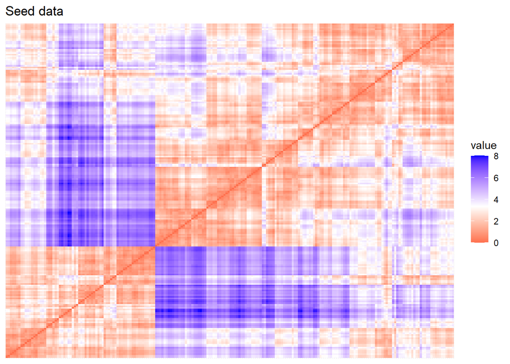

```r
fviz_dist(dist(df.scaled), show_labels = FALSE)+labs(title = "Seed data")
```

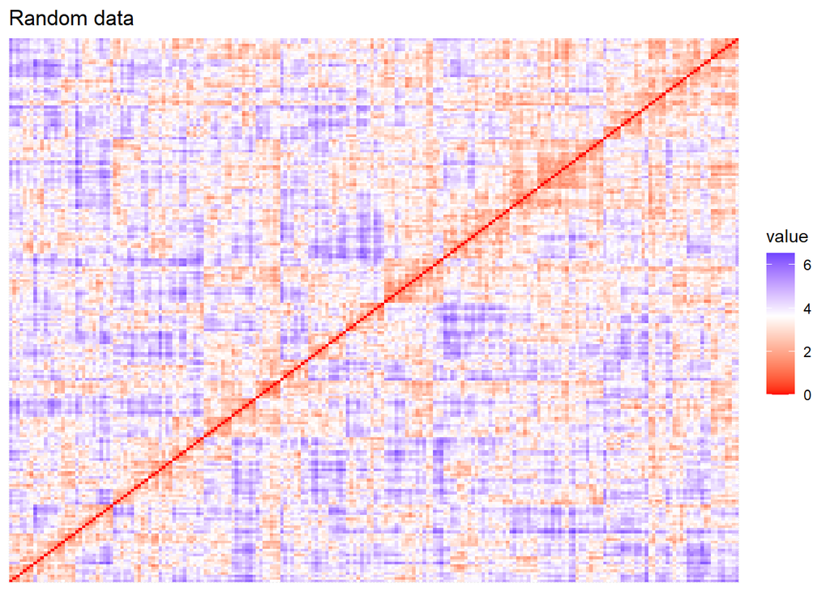

```r
scaled.Random_seed<-scale(random_seed[-8])
fviz_dist(dist(scaled.Random_seed), show_labels = FALSE)+labs(title = "Random data")
```

## DETERMINING NUMBER OF CLUSTER

```r
## fviz_nbclust function
set.seed(1)
manhDist <- dist(df.scaled,method = "manhattan")
```

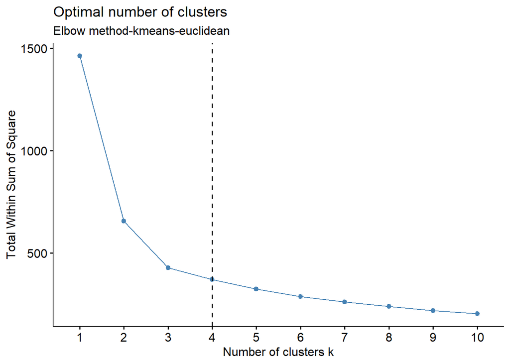

```r
# Elbow method
par(mfrow=c(2,2))
fviz_nbclust(df.scaled, kmeans, nstart = 25, method = "wss") +geom_vline(xintercept = 4, linetype = 2)+labs(subtitle = "Elbow method-kmeans-euclidean")
```

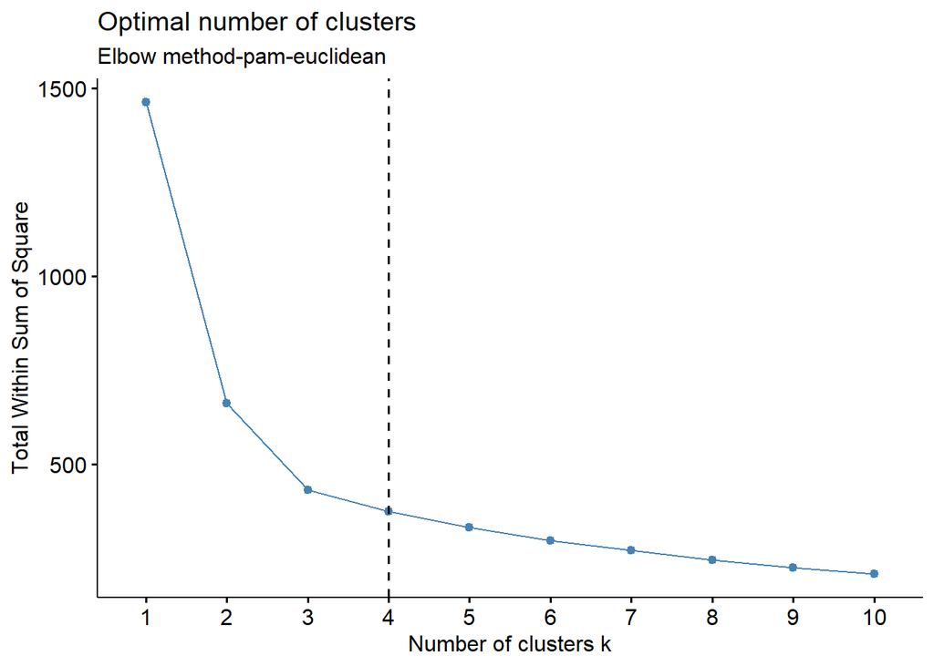

```r
fviz_nbclust(df.scaled, pam, nstart = 25, method = "wss") +geom_vline(xintercept = 4, linetype = 2)+labs(subtitle = "Elbow method-pam-euclidean")
```

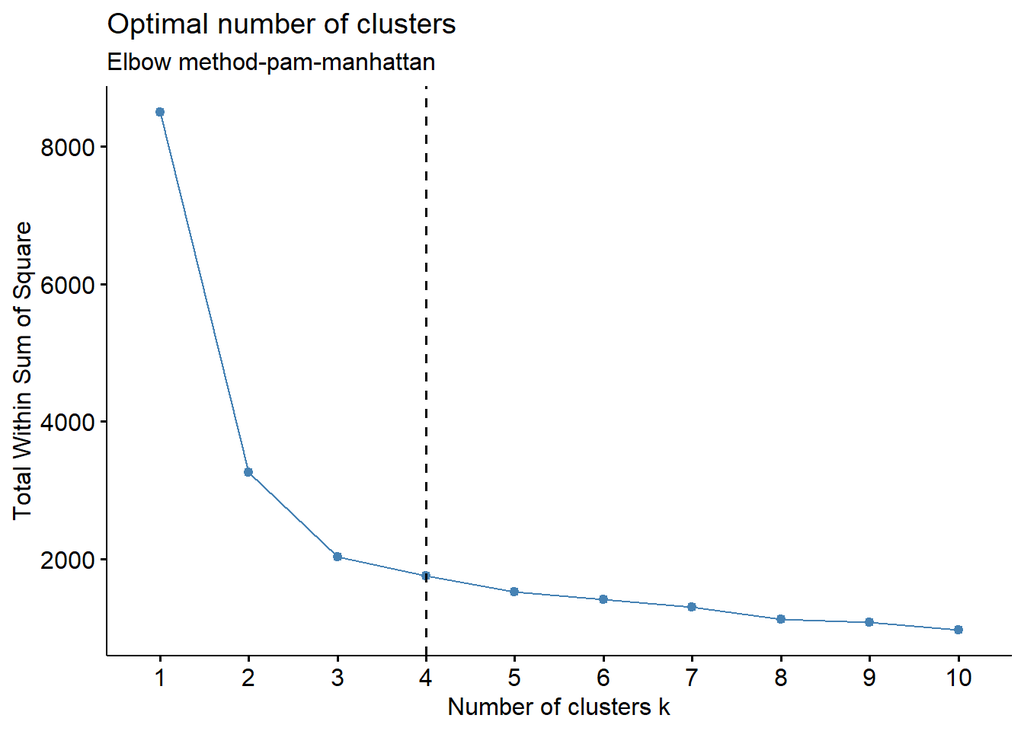

```r
fviz_nbclust(df.scaled, pam,manhDist, nstart = 25, method = "wss") +geom_vline(xintercept = 4, linetype = 2)+labs(subtitle = "Elbow method-pam-manhattan")
```

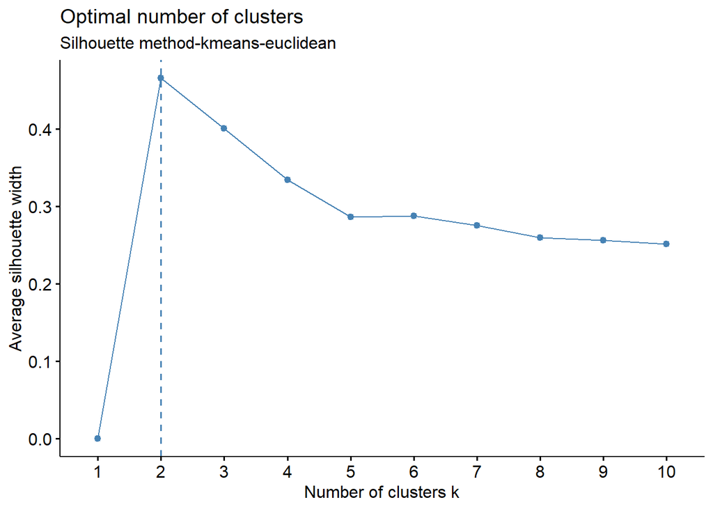

```r
# Silhouette method
set.seed(1)
fviz_nbclust(df.scaled, kmeans,nstart = 25, method = "silhouette")+labs(subtitle = "Silhouette method-kmeans-euclidean")
```

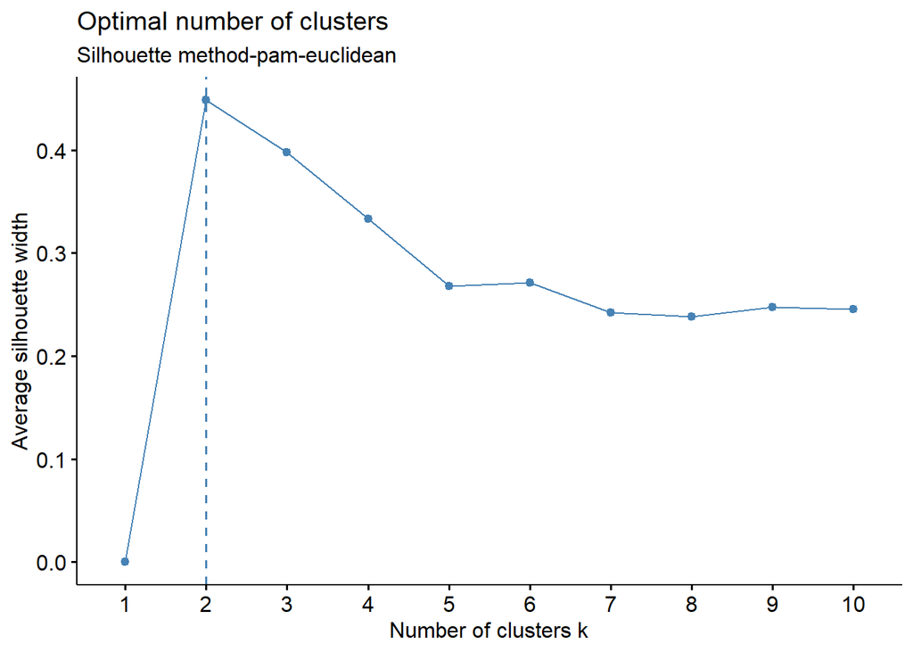

```r
fviz_nbclust(df.scaled, pam,nstart = 25, method = "silhouette")+labs(subtitle = "Silhouette method-pam-euclidean")
```

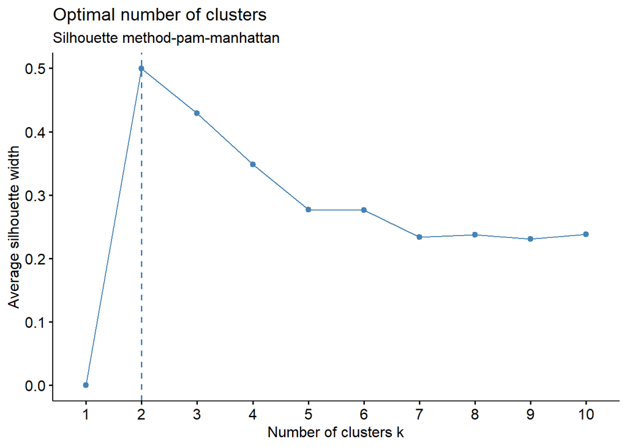

```r
fviz_nbclust(df.scaled, pam, manhDist ,nstart = 25, method = "silhouette")+labs(subtitle = "Silhouette method-pam-manhattan")
```

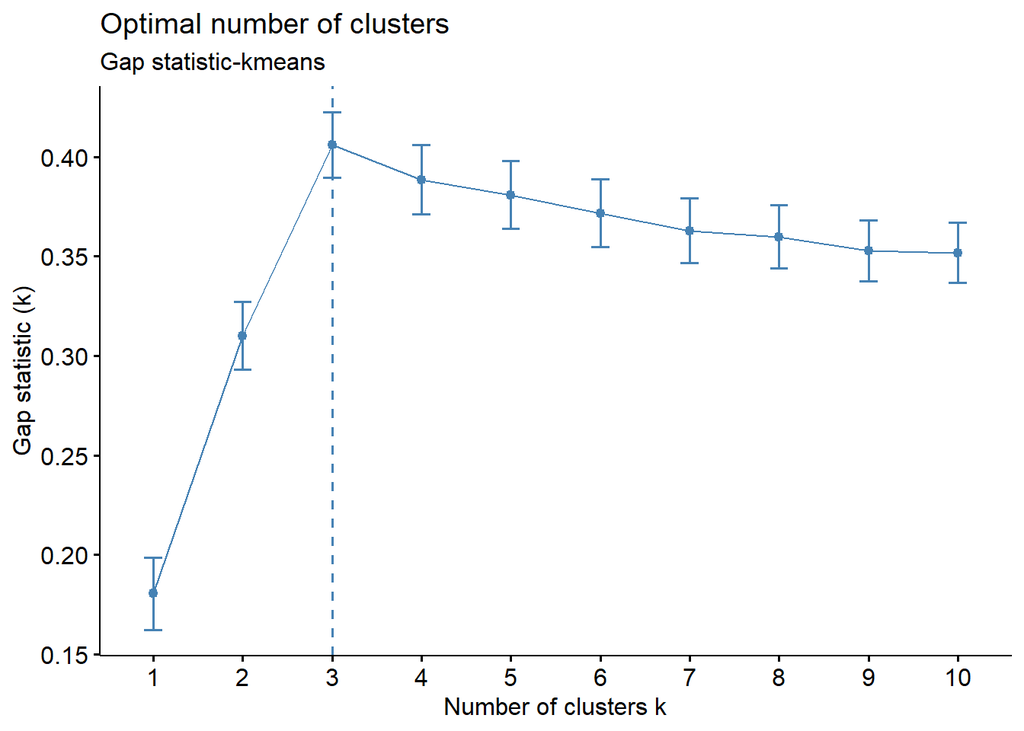

```r
# Gap statistic
# nboot = 50 to keep the function speedy.
# recommended value: nboot = 500 for your analysis.
# Use verbose = FALSE to hide computing progression.
set.seed(1)
fviz_nbclust(df.scaled, kmeans, nstart = 25, method = "gap_stat", nboot = 500)+labs(subtitle = "Gap statistic-kmeans")
```

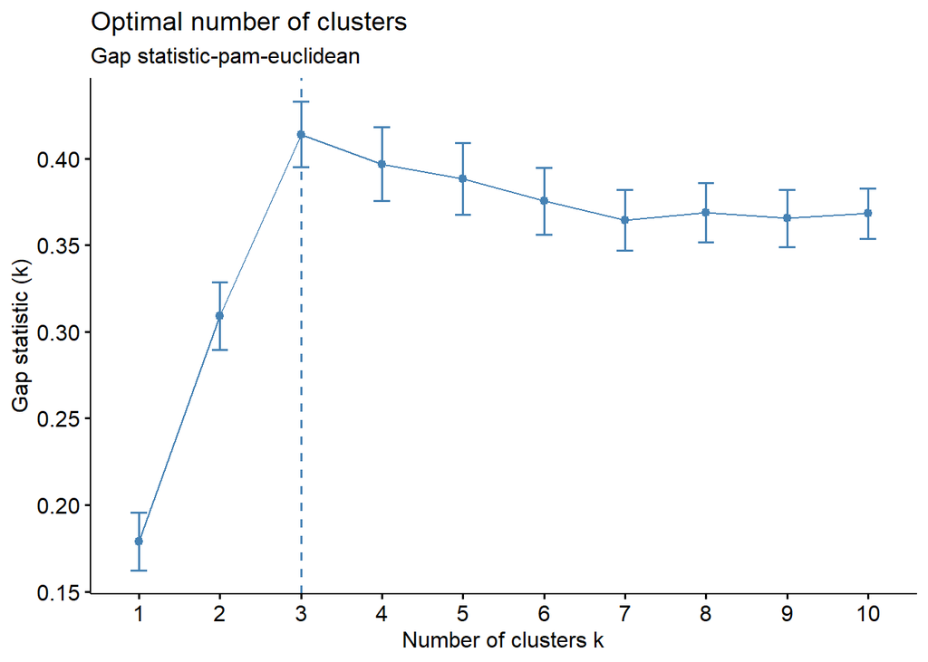

```r
fviz_nbclust(df.scaled, pam, nstart = 25, method = "gap_stat", nboot = 50)+labs(subtitle = "Gap statistic-pam-euclidean")
```

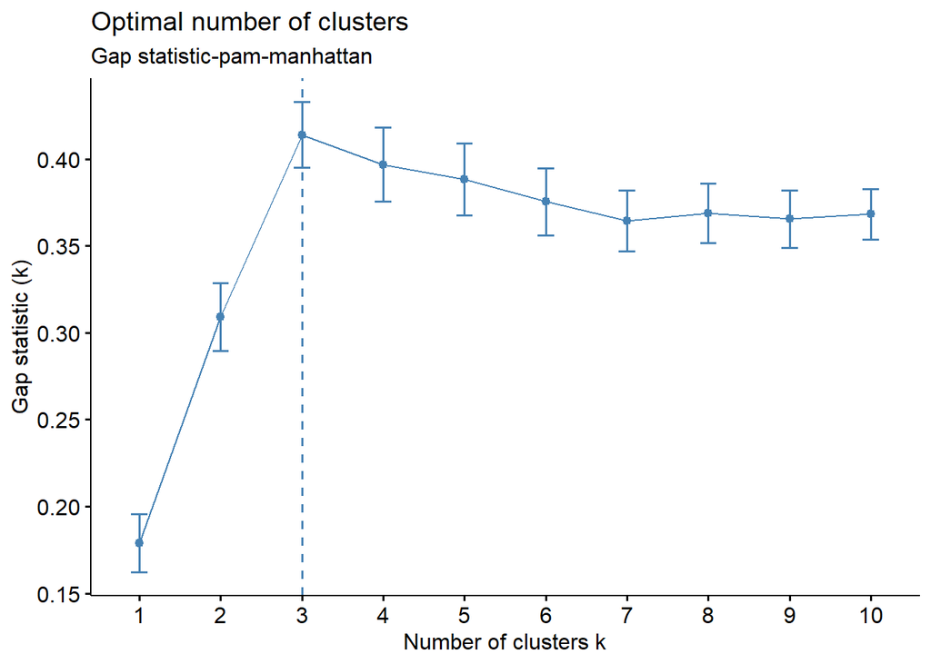

```r
fviz_nbclust(df.scaled, pam,manhDist, nstart = 25, method = "gap_stat", nboot = 50)+labs(subtitle = "Gap statistic-pam-manhattan")
```

Now, we can proceed with the hierarchical cluster analysis. The first clustering algorithm that I applied is the agglomerative hierarchical clustering, that is a “bottom-up” approach: each observation starts in its own cluster (leaf), and pairs of cluster are merged as on e moves up the hierarchy. This process goes on until there is just one single big cluster (root). In this case the leaves are 210, and for every step, the algorithm merges pairs of cluster with the lowest dissimilarity according to a different given linkage method, and then it moves up the hierarchy, until there is just one single big cluster, with all the observations within, by building a sort of tree diagram called dendrogram. I will calculate the dissimilarity matrix using two different distances: the Euclidean, that is the most used, and the Manhattan, that reduces the effects of outliers. I start using the Euclidean distance, and respectively single, average and complete linkage method

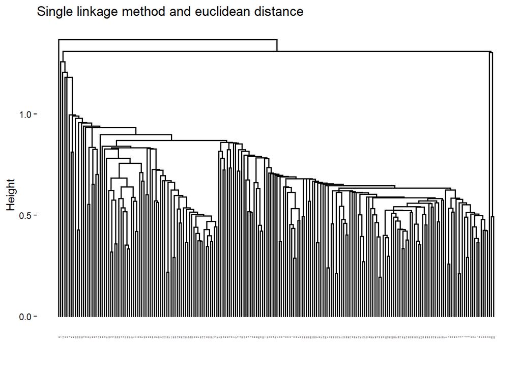

```r
# Compute the dissimilarity matrix
res.dist <- dist(df.scaled, method = "euclidean")
res.dist2 <- dist(df.scaled, method = "manhattan")
res.hc<-hclust(d=res.dist,method="single")
#dendogram
fviz_dend(res.hc,cex=0.1,main="Single linkage method and euclidean distance")
```

now we compute **cophenetic distance**

```r
#compute cophenetic distance
cor(res.dist,cophenetic(res.hc))
```

```
## [1] 0.4266838
```

One way to measure how well the cluster tree generated by the hclust() function reflects our data is to compute the correlation between the cop henetic distances and the original distances generated by the dist() function. The cophenetic dissimilarity/distance of two units is a measure of how similar those two units have to be in order to be grouped into the same cluster. From a practical point of view, the cophenetic distance between two units is the height of the dendrogram where the two branches that include the two units merge in to a single branch (height of the fusion)

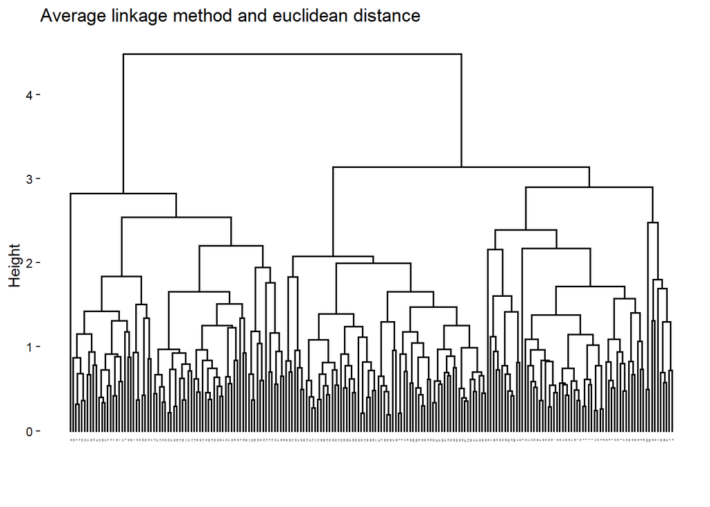

```r
res.hc<-hclust(d=res.dist,method="average")
fviz_dend(res.hc,cex=0.1,main="Average linkage method and euclidean distance")
```

visualizing COMPLETE LINKAGE

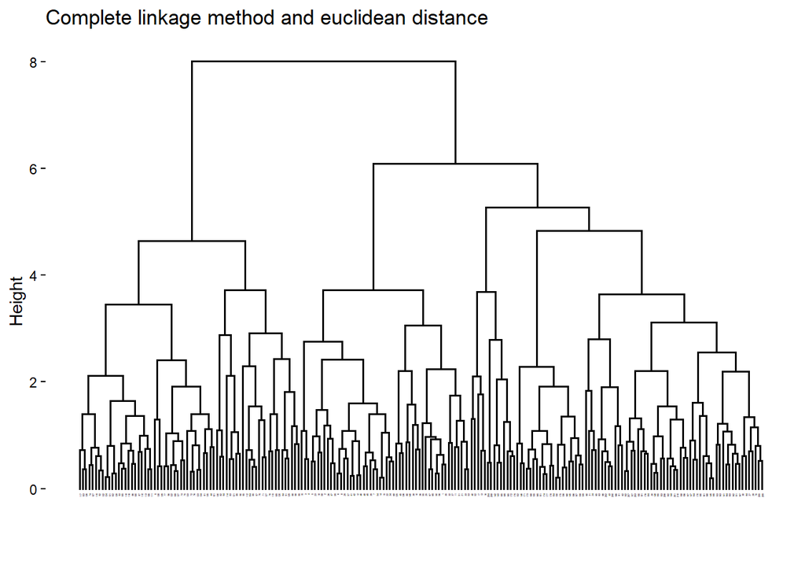

```r
res.hc<-hclust(d=res.dist,method="complete")
fviz_dend(res.hc,cex=0.1,main="Complete linkage method and euclidean distance")
```

```r
cor(res.dist,cophenetic(res.hc))
```

```
## [1] 0.7129629
```

```r
cor(res.dist,cophenetic(res.hc))
```

```
## [1] 0.7129629
```

vizuaizing SINGLE wih MANHATTAN DISTANCE

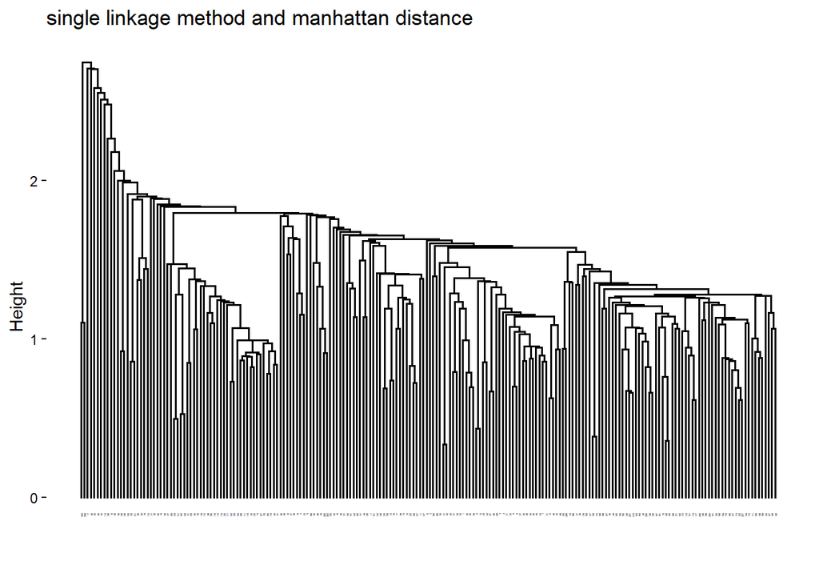

```r
res.hc<-hclust(d=res.dist2,method="single")
fviz_dend(res.hc,cex=0.1,main="single linkage method and manhattan distance")
```

```r
cor(res.dist2,cophenetic(res.hc))
```

```
## [1] 0.3632612
```

now visualizing AVERAGE linkage with MANHATTAN

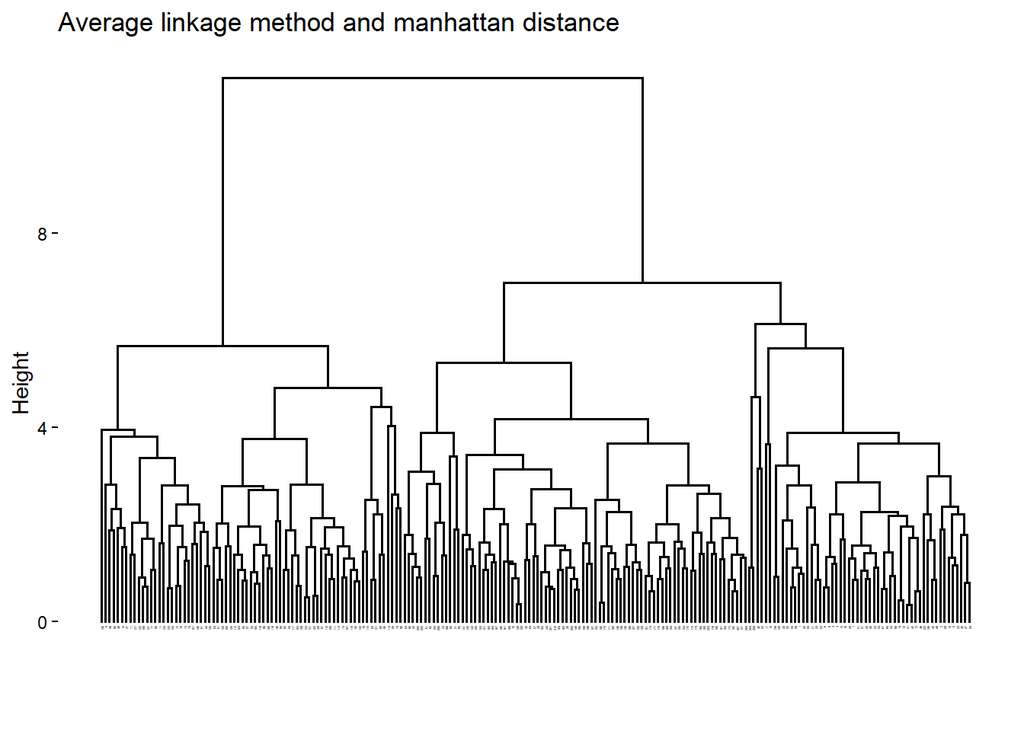

```r
res.hc<-hclust(d=res.dist2,method="average")
fviz_dend(res.hc,cex=0.1,main="Average linkage method and manhattan distance",)
```

```r
cor(res.dist2,cophenetic(res.hc))
```

```
## [1] 0.7606175
```

now visualizing COMPLETE LINKAGE and MANHATTAN

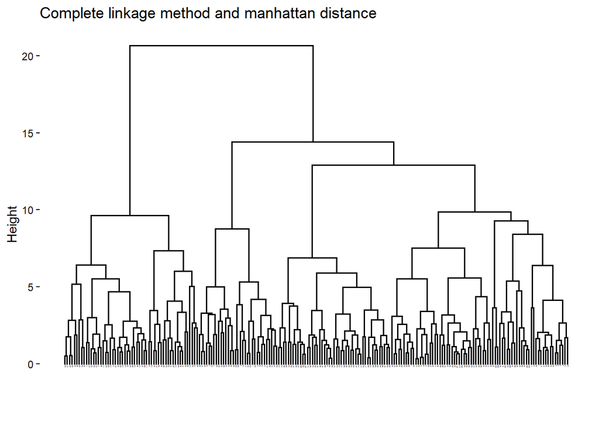

```r
res.hc<-hclust(d=res.dist2,method="complete")
fviz_dend(res.hc,cex=0.1,main="Complete linkage method and manhattan distance")
```

```r
cor(res.dist2,cophenetic(res.hc))
```

```
## [1] 0.743256
```

Agglomerative hierarchical clustering methods can be divided into two groups: those based on **distances between individual observations** (single, average, and complete linkage) and those that use **cluster centroids** (centroid and Ward’s methods).

Centroid and Ward’s linkage treat each cluster as represented by its center, making them suitable only for numerical datasets. Among them, **Ward’s method** is particularly effective because it **iteratively minimizes the within-cluster sum of squares (WSS)** while **maximizing the between-cluster sum of squares (BSS)**. Consequently, it tends to produce compact, well-separated clusters based on Euclidean distance

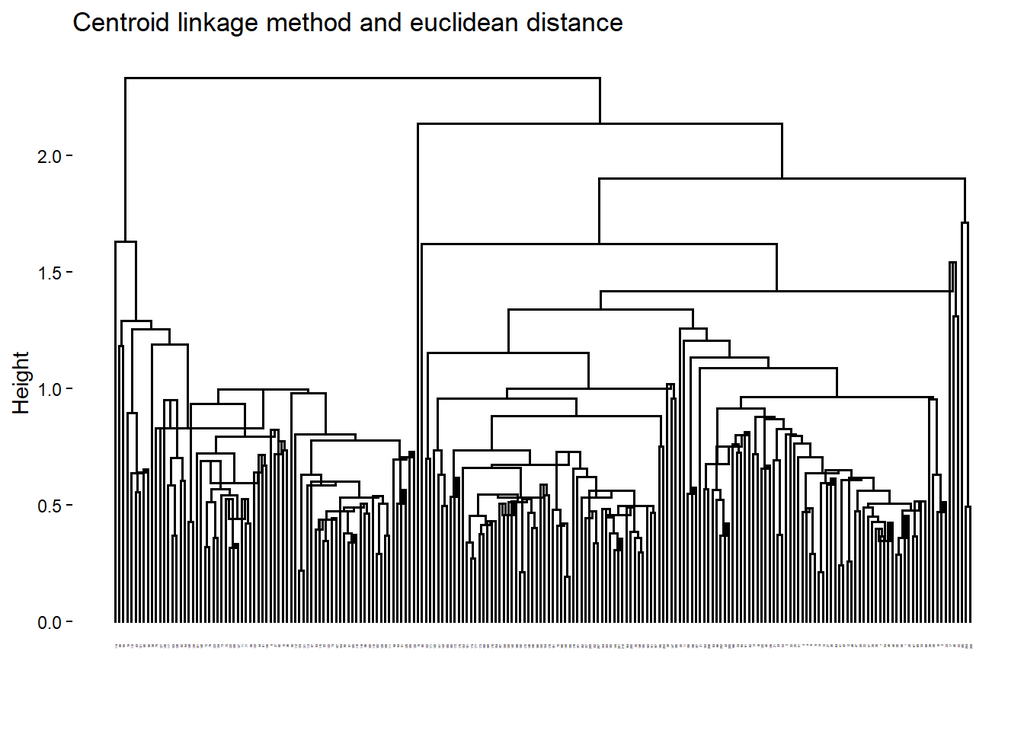

```r
#centroid and ward method
res.centroid<-hclust(d=res.dist,method="centroid")
fviz_dend(res.centroid,cex=0.1,main="Centroid linkage method and euclidean distance")
```

```r
cor(res.dist,cophenetic(res.centroid))
```

```
## [1] 0.7382693
```

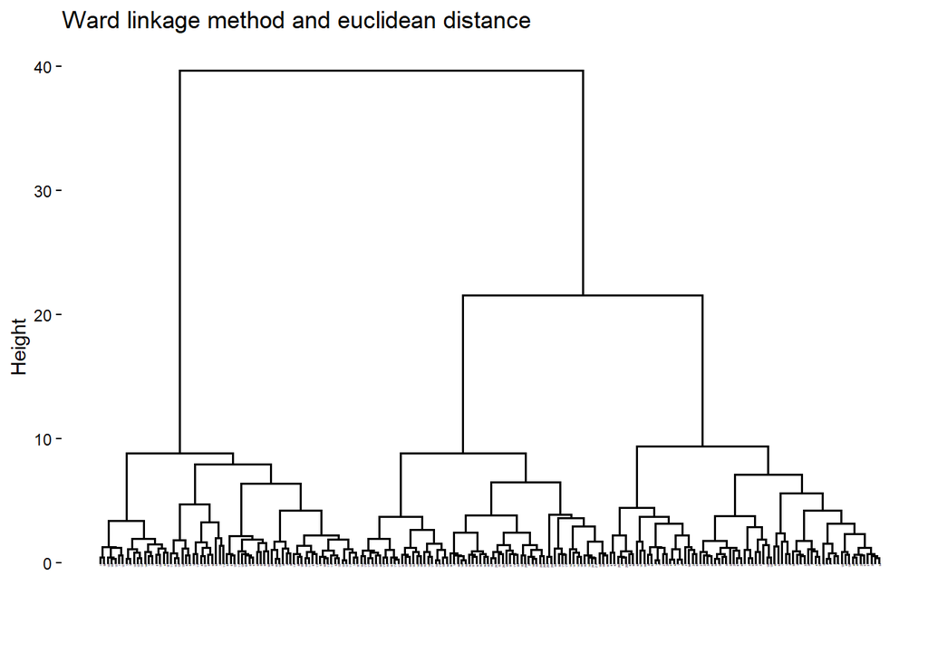

```r
res.ward<-hclust(d=res.dist,method="ward.D2")
fviz_dend(res.ward,cex=0.1,main="Ward linkage method and euclidean distance")
```

```r
cor(res.dist,cophenetic(res.ward))
```

```
## [1] 0.7285529
```

```r
library(NbClust)
set.seed(1)

# Calcolo NbClust
nb <- NbClust(df.scaled,
              distance = "euclidean",
              min.nc = 2,
              max.nc = 10,
              method = "kmeans")
```

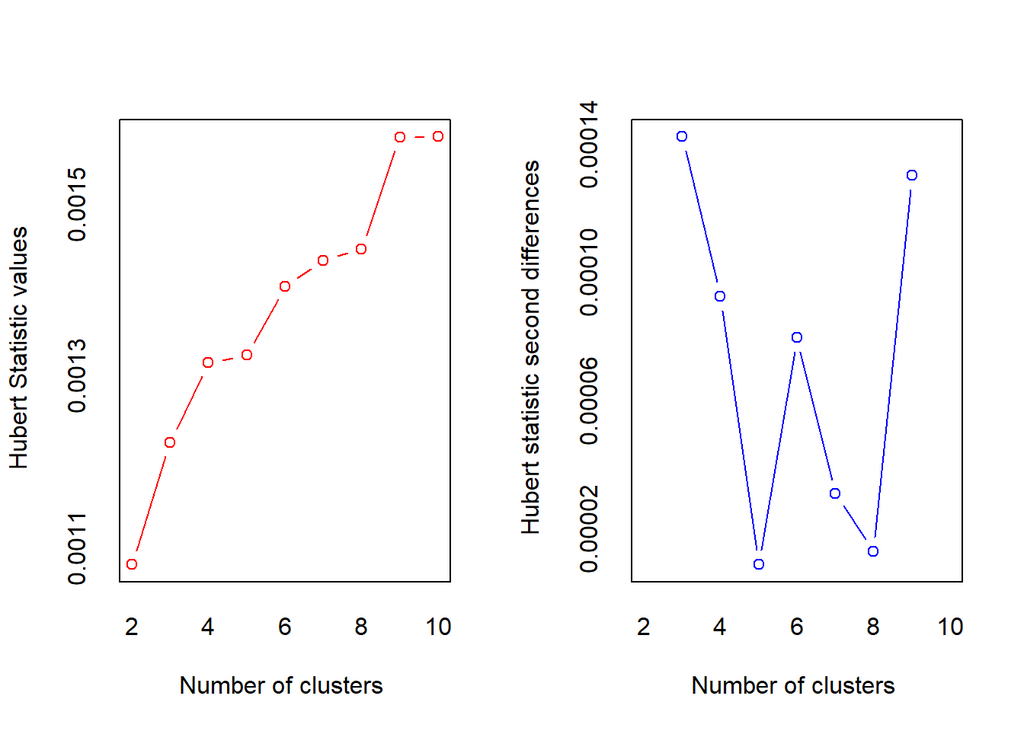

```
## *** : The Hubert index is a graphical method of determining the number of clusters.
##                 In the plot of Hubert index, we seek a significant knee that corresponds to a
##                 significant increase of the value of the measure i.e the significant peak in Hubert
##                 index second differences plot.
##
```

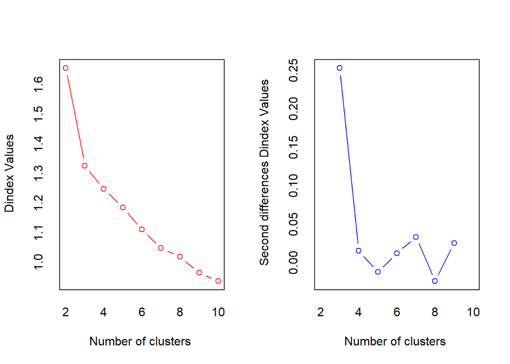

```
## *** : The D index is a graphical method of determining the number of clusters.
##                 In the plot of D index, we seek a significant knee (the significant peak in Dindex
##                 second differences plot) that corresponds to a significant increase of the value of
##                 the measure.
##
## * Among all indices:
## * 10 proposed 2 as the best number of clusters
## * 11 proposed 3 as the best number of clusters
## * 1 proposed 6 as the best number of clusters
## * 1 proposed 10 as the best number of clusters
##
##                    ***** Conclusion *****
##
## * According to the majority rule, the best number of clusters is  3
##
##
```

```r
# Tabella dei K suggeriti dai diversi indici
best_k_table <- table(nb$Best.nc[1, ])
print(best_k_table)
```

```
##
##  0  1  2  3  6 10
##  2  1 10 11  1  1
```

[figure not shown]

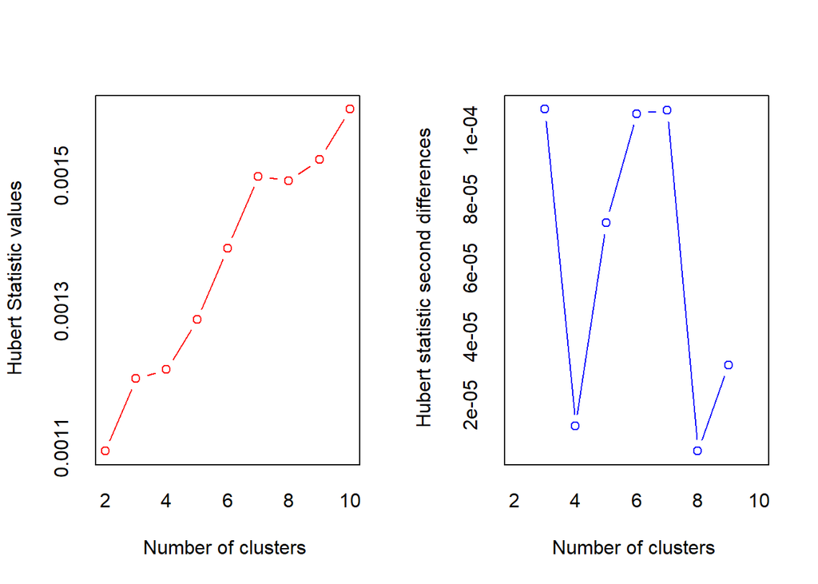

```
## *** : The Hubert index is a graphical method of determining the number of clusters.
##                 In the plot of Hubert index, we seek a significant knee that corresponds to a
##                 significant increase of the value of the measure i.e the significant peak in Hubert
##                 index second differences plot.
##
```

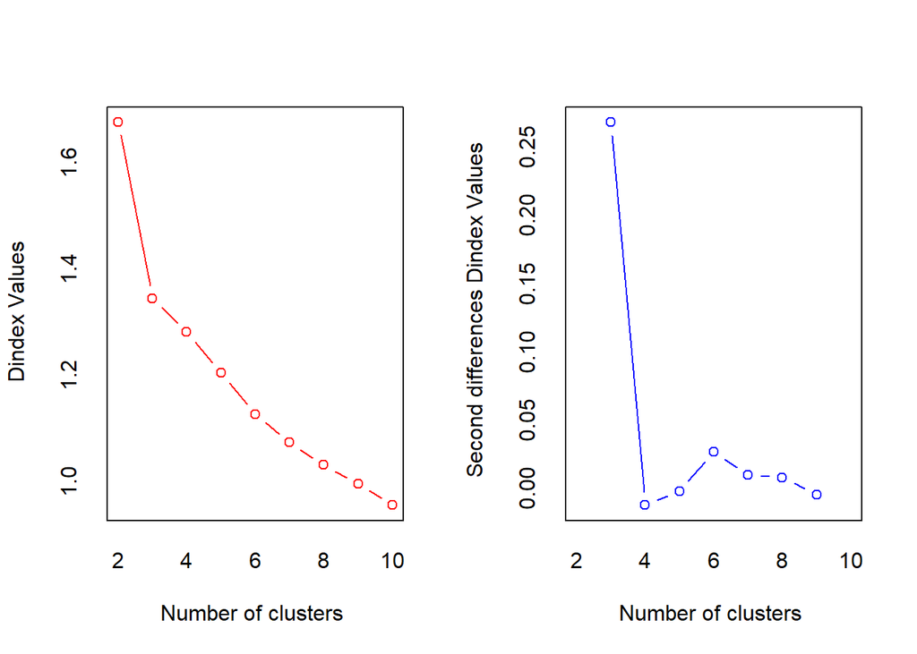

```
## *** : The D index is a graphical method of determining the number of clusters.
##                 In the plot of D index, we seek a significant knee (the significant peak in Dindex
##                 second differences plot) that corresponds to a significant increase of the value of
##                 the measure.
##
## * Among all indices:
## * 7 proposed 2 as the best number of clusters
## * 13 proposed 3 as the best number of clusters
## * 1 proposed 6 as the best number of clusters
## * 2 proposed 10 as the best number of clusters
##
##                    ***** Conclusion *****
##
## * According to the majority rule, the best number of clusters is  3
##
##
```

```
##
##  0  1  2  3  6 10
##  2  1  7 13  1  2
```

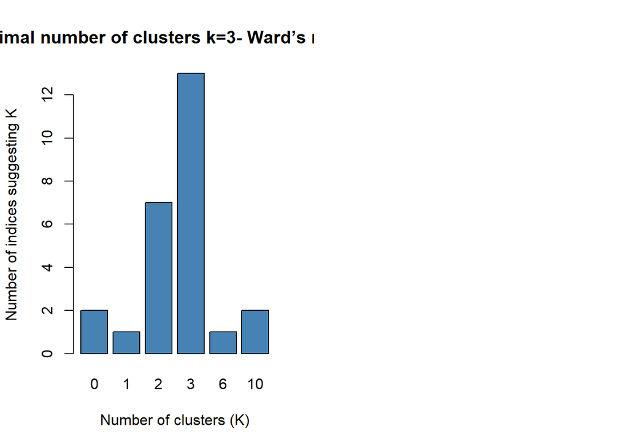

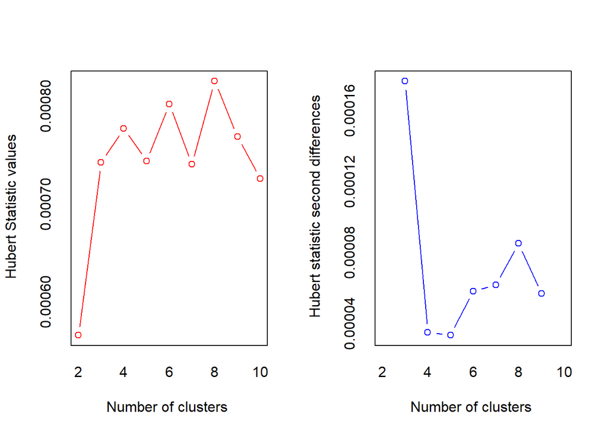

```
## *** : The Hubert index is a graphical method of determining the number of clusters.
##                 In the plot of Hubert index, we seek a significant knee that corresponds to a
##                 significant increase of the value of the measure i.e the significant peak in Hubert
##                 index second differences plot.
##
```

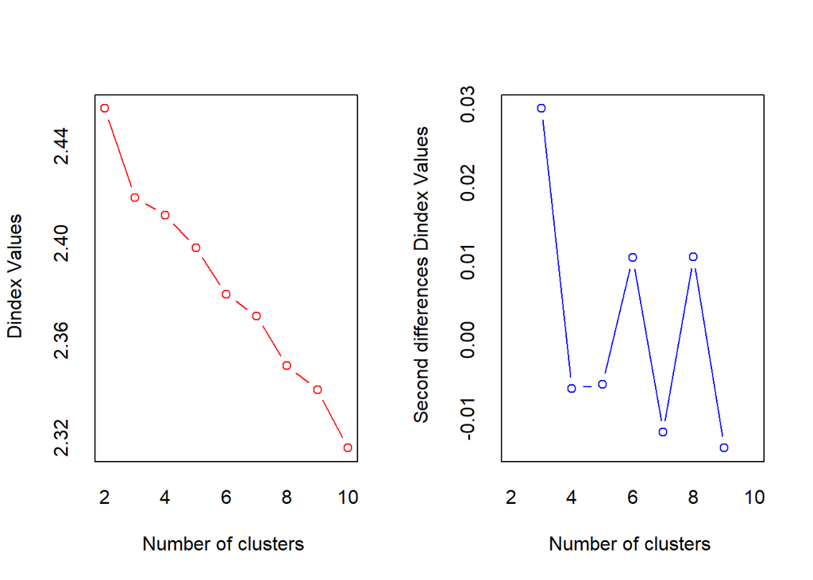

```
## *** : The D index is a graphical method of determining the number of clusters.
##                 In the plot of D index, we seek a significant knee (the significant peak in Dindex
##                 second differences plot) that corresponds to a significant increase of the value of
##                 the measure.
##
## * Among all indices:
## * 8 proposed 2 as the best number of clusters
## * 8 proposed 3 as the best number of clusters
## * 2 proposed 8 as the best number of clusters
## * 1 proposed 9 as the best number of clusters
## * 4 proposed 10 as the best number of clusters
##
##                    ***** Conclusion *****
##
## * According to the majority rule, the best number of clusters is  2
##
##
```

```
##
##  0  1  2  3  8  9 10
##  2  1  8  8  2  1  4
```

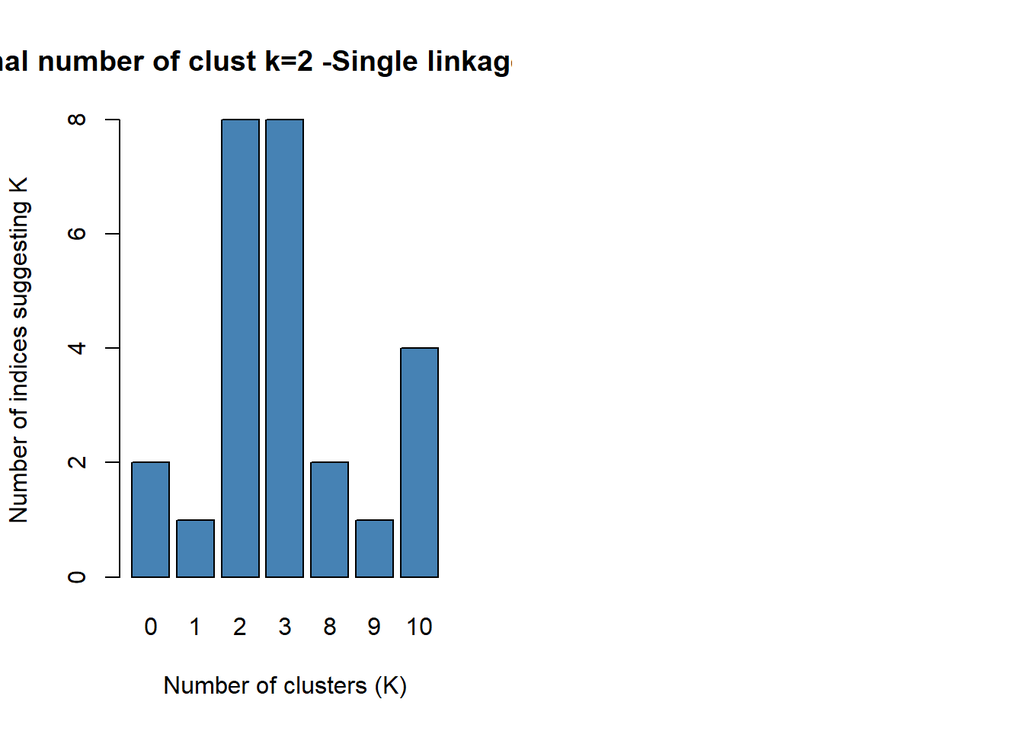

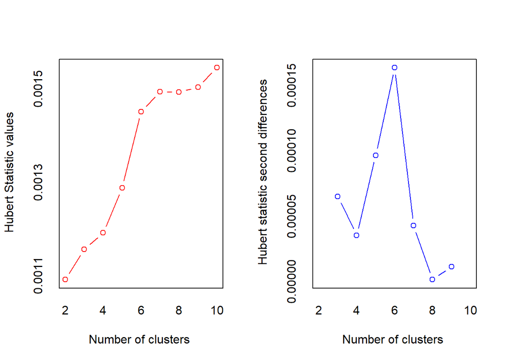

```
## *** : The Hubert index is a graphical method of determining the number of clusters.
##                 In the plot of Hubert index, we seek a significant knee that corresponds to a
##                 significant increase of the value of the measure i.e the significant peak in Hubert
##                 index second differences plot.
##
```

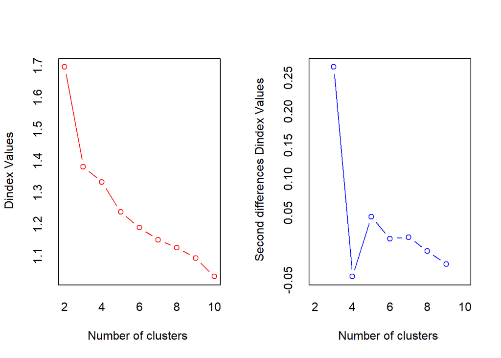

```
## *** : The D index is a graphical method of determining the number of clusters.
##                 In the plot of D index, we seek a significant knee (the significant peak in Dindex
##                 second differences plot) that corresponds to a significant increase of the value of
##                 the measure.
##
## * Among all indices:
## * 7 proposed 2 as the best number of clusters
## * 16 proposed 3 as the best number of clusters
## * 1 proposed 10 as the best number of clusters
##
##                    ***** Conclusion *****
##
## * According to the majority rule, the best number of clusters is  3
##
##
```

```
##
##  0  2  3 10
##  2  7 16  1
```

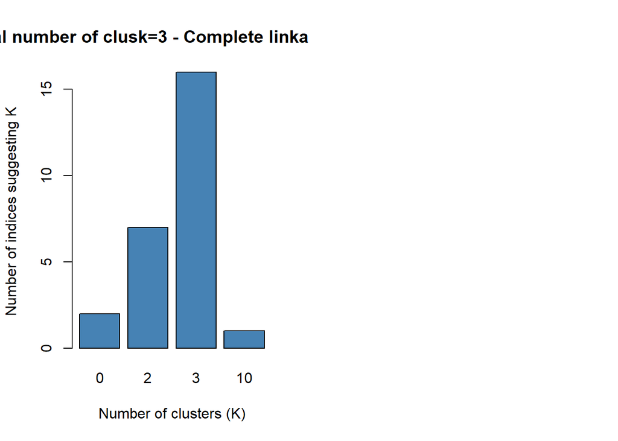

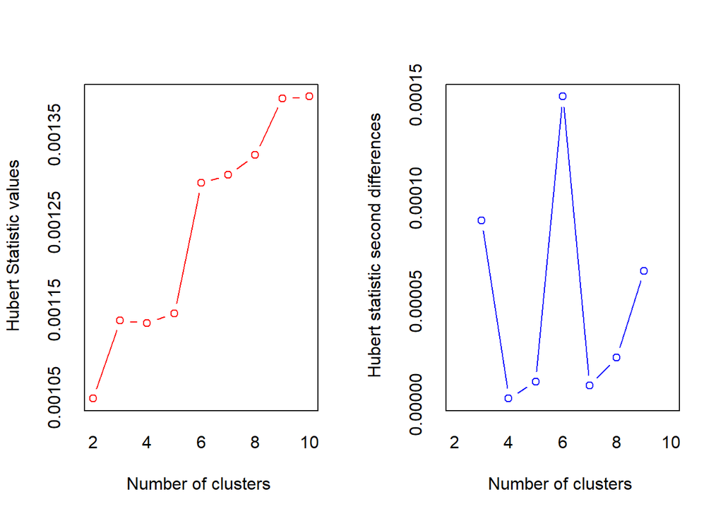

```
## *** : The Hubert index is a graphical method of determining the number of clusters.
##                 In the plot of Hubert index, we seek a significant knee that corresponds to a
##                 significant increase of the value of the measure i.e the significant peak in Hubert
##                 index second differences plot.
##
```

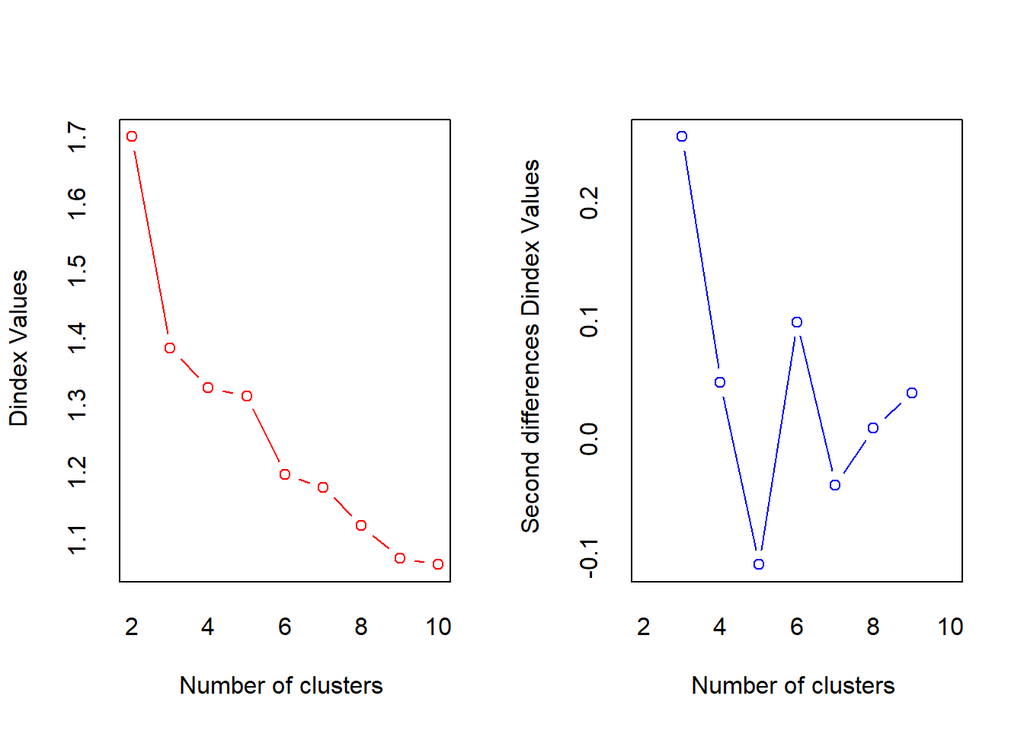

```
## *** : The D index is a graphical method of determining the number of clusters.
##                 In the plot of D index, we seek a significant knee (the significant peak in Dindex
##                 second differences plot) that corresponds to a significant increase of the value of
##                 the measure.
##
## * Among all indices:
## * 5 proposed 2 as the best number of clusters
## * 9 proposed 3 as the best number of clusters
## * 3 proposed 4 as the best number of clusters
## * 1 proposed 5 as the best number of clusters
## * 3 proposed 6 as the best number of clusters
## * 1 proposed 8 as the best number of clusters
## * 1 proposed 10 as the best number of clusters
##
##                    ***** Conclusion *****
##
## * According to the majority rule, the best number of clusters is  3
##
##
```

```
##
##  0  1  2  3  4  5  6  8 10
##  2  1  5  9  3  1  3  1  1
```

[1 more figures not shown]

```r
# Grafico a barre dei voti per ogni K
barplot(best_k_table,
        xlab = "Number of cluster  (K)",
        ylab = "Frequency  among all indices",
        main = "Optimal number of cluster k=3",
        col = "steelblue")
```

As we can seen befotr, k=3 and later k=2 seem to be the two candidate to better fit the optimal number of cluster in our data

## choosing the alghorithm

```r
clmethods <- c("hierarchical","kmeans","pam")
intern <- clValid(df.scaled, nClust = 2:6,clMethods = clmethods,
validation = "internal")
summary(intern)
```

```
##
## Clustering Methods:
##  hierarchical kmeans pam
##
## Cluster sizes:
##  2 3 4 5 6
##
## Validation Measures:
##                                  2       3       4       5       6
##
## hierarchical Connectivity  17.7754 39.1413 42.9798 46.1087 54.3317
##              Dunn           0.1132  0.0997  0.1058  0.1058  0.1157
##              Silhouette     0.4413  0.3760  0.3549  0.2752  0.2903
## kmeans       Connectivity  16.8964 39.5476 63.6409 79.9706 98.7131
##              Dunn           0.0870  0.1188  0.0888  0.0814  0.0814
##              Silhouette     0.4658  0.4007  0.3379  0.2881  0.2740
## pam          Connectivity  28.5028 41.4413 55.4944 73.2921 96.9325
##              Dunn           0.0588  0.1115  0.1114  0.0816  0.0817
##              Silhouette     0.4648  0.3982  0.3335  0.2678  0.2336
##
## Optimal Scores:
##
##              Score   Method Clusters
## Connectivity 16.8964 kmeans 2
## Dunn          0.1188 kmeans 3
## Silhouette    0.4658 kmeans 2
```

```r
stability <- clValid(df.scaled, nClust = 2:6,clMethods = clmethods, validation = "stability")
 summary(stability)
```

```
##
## Clustering Methods:
##  hierarchical kmeans pam
##
## Cluster sizes:
##  2 3 4 5 6
##
## Validation Measures:
##                        2      3      4      5      6
##
## hierarchical APN  0.0960 0.1254 0.1957 0.2264 0.2066
##              AD   2.4594 2.3202 2.0326 2.0170 1.9103
##              ADM  0.4000 0.9008 0.5868 0.6321 0.6470
##              FOM  0.7000 0.6717 0.5730 0.5730 0.5649
## kmeans       APN  0.0351 0.0976 0.1641 0.2036 0.3298
##              AD   2.3330 1.9462 1.8844 1.7667 1.7647
##              ADM  0.1632 0.3088 0.4636 0.5015 0.7466
##              FOM  0.6714 0.5707 0.5655 0.5236 0.5133
## pam          APN  0.0859 0.0950 0.2206 0.1390 0.1918
##              AD   2.4054 1.9467 1.8819 1.7028 1.6608
##              ADM  0.3633 0.2889 0.5510 0.3144 0.3885
##              FOM  0.6777 0.5675 0.5375 0.5095 0.5102
##
## Optimal Scores:
##
##     Score  Method Clusters
## APN 0.0351 kmeans 2
## AD  1.6608 pam    6
## ADM 0.1632 kmeans 2
## FOM 0.5095 pam    5
```

### Cluster Validation

To further evaluate the clustering performance, both **internal** and **stability** validation measures were computed using the `clValid` package.  
These indices assess the quality and robustness of the clusters obtained through different algorithms (hierarchical, k-means, and PAM) across a range of possible cluster numbers (K = 2–6).

#### Stability Validation

The stability validation confirms that the **k-means algorithm** also yields the most stable clustering configuration, showing the best APN (0.0351) and ADM (0.1632) values for **2 clusters**.  
These findings suggest that the **2-cluster solution** is not only internally coherent but also stable across resampling, indicating strong consistency in the underlying data structure.

## External Validation

In the external validation step, the goal is to compare the clusters identified by the algorithms (k-means, PAM, or hierarchical clustering) with an external reference — in this case, the true labels of the dataset.  
This comparison allows us to quantify the agreement between the obtained clusters and the known classes using two measures:  
the **Adjusted Rand Index (ARI)** and **Meila’s Variation of Information (VI)**.

The Adjusted Rand Index ranges from **-1** (no agreement) to **1** (perfect agreement), while Meila’s VI measures the amount of information lost between the two partitions — therefore, **smaller VI values indicate better agreement**.

We start by computing a cross-tabulation (confusion matrix) between the true labels (`seed$target`) and the clusters obtained with k-means (`km.res$cluster`), followed by the external validation indices.

```r
km.res<-eclust(df.scaled,"kmeans",k=3,nstart=25)
```

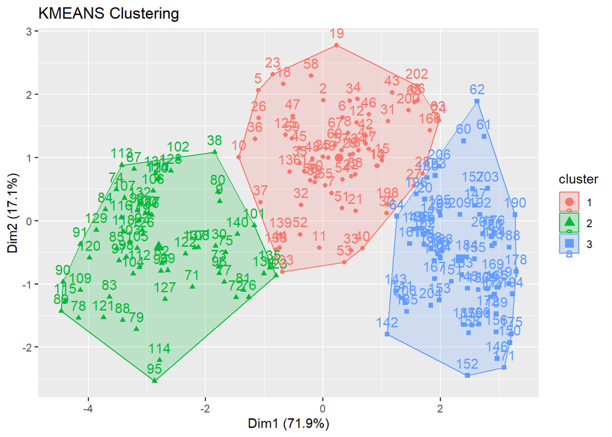

```r
table(seed$target,km.res$cluster)
```

```
##
##      1  2  3
##   1 62  2  6
##   2  5 65  0
##   3  4  0 66
```

```r
library(fpc)

# Compute external validation indices (Adjusted Rand Index and Meila’s VI)
clust_stats <- cluster.stats(d = dist(df.scaled), seed$target,km.res$cluster)

#Correct Rand index
clust_stats$corrected.rand
```

```
## [1] 0.7732937
```

```r
#Meilaìs VI index
clust_stats$vi
```

```
## [1] 0.5978132
```

## Pam

```r
pam.res<-eclust(df.scaled,"pam",k=3,nstart=25)
```

```r
table(seed$target,pam.res$cluster)
```

```
##
##      1  2  3
##   1 64  1  5
##   2  9 61  0
##   3  4  0 66
```

```r
clust_stats<-cluster.stats(d=dist(df.scaled),seed$target,pam.res$cluster)
clust_stats$corrected.rand
```

```
## [1] 0.7469561
```

```r
clust_stats$vi
```

```
## [1] 0.6264608
```

```r
res.hc<-eclust(df.scaled,"hclust",k=3,nstart=25)
table(seed$target,res.hc$cluster)
```

```
##
##      1  2  3
##   1 64  4  2
##   2  4 66  0
##   3  5  0 65
```

```r
clust_stats<-cluster.stats(d=dist(df.scaled),seed$target,res.hc$cluster)
clust_stats$corrected.rand
```

```
## [1] 0.7969983
```

```r
clust_stats$vi
```

```
## [1] 0.5495578
```

### Model-based Clustering

One disadvantage of traditional clustering methods, such as hierarchical and partitioning clustering algorithms, is that they are largely heuristic and not based on formal models. This means that formal inference is not possible.

An alternative is model-based clustering, which considers the sample observations x1, …, xn as coming from a distribution that is mixture of two or more, say K, distribution, commonly one for each cluster. Each component, k=1,…,K, is described by a probability density or mass function and has an asso ciated probability density or mass function and has an associated probability or “weight” in the mixture. Unlike hierarchical and partitioning clustering methods, the model-based clustering uses a soft assignment, where each data point has a probability of belonging to each cluster.

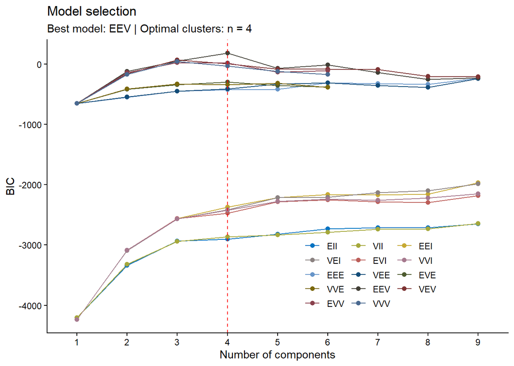

```r
 set.seed(1)
mod<-Mclust(df.scaled)
fviz_mclust(mod, "BIC",palette="jco")
```

Results indicated that the best-fitting model was **EEV (ellipsoidal, equal volume and shape)** with **four clusters**.  
This model provides a probabilistic framework for clustering, automatically estimating both the number of groups and their underlying covariance structures.

```r
summary(mod)
```

```
## ----------------------------------------------------
## Gaussian finite mixture model fitted by EM algorithm
## ----------------------------------------------------
##
## Mclust EEV (ellipsoidal, equal volume and shape) model with 4 components:
##
##  log-likelihood   n  df      BIC      ICL
##        416.1655 210 122 179.9839 172.5306
##
## Clustering table:
##  1  2  3  4
## 50 49 45 66
```

```r
summary(mod$BIC)
```

[output not shown]

We can take a look at the information contained in the model and we can see that the BIC has a log-likelihood of 416, that it uses 122 parameters, that the BIC value is 179 and that the ICL (Integrated Complet ed Likelihood) is 172 and that there are 4 clusters. The three best model configurations are:

```r
head(round(mod$z, 6), 30) # Probability to belong to a given cluster
```

```
##           [,1] [,2]     [,3]     [,4]
##  [1,] 0.999901    0 0.000099 0.000000
##  [2,] 0.917549    0 0.082451 0.000000
##  [3,] 0.390903    0 0.609097 0.000000
##  [4,] 0.000000    0 1.000000 0.000000
##  [5,] 1.000000    0 0.000000 0.000000
##  [6,] 0.097649    0 0.902351 0.000000
##  [7,] 0.606646    0 0.393354 0.000000
##  [8,] 0.000000    0 1.000000 0.000000
##  [9,] 1.000000    0 0.000000 0.000000
## [10,] 1.000000    0 0.000000 0.000000
## [11,] 0.999985    0 0.000015 0.000000
## [12,] 0.000000    0 1.000000 0.000000
## [13,] 0.000000    0 1.000000 0.000000
## [14,] 0.000000    0 1.000000 0.000000
```

[output cut: 16 more lines]

It give us the probability that every units belong to every cluster. Easly we can get the vector related to the hard classification (cluster of membership of each unit)

```r
 head(mod$classification, 30) # Cluster assignment of each observation
```

```
##  [1] 1 1 3 3 1 3 1 3 1 1 1 3 3 3 3 1 3 1 1 3 3 3 1 4 1 1 3 3 3 3
```

I plot the data according to classification vector, an the real seed$target

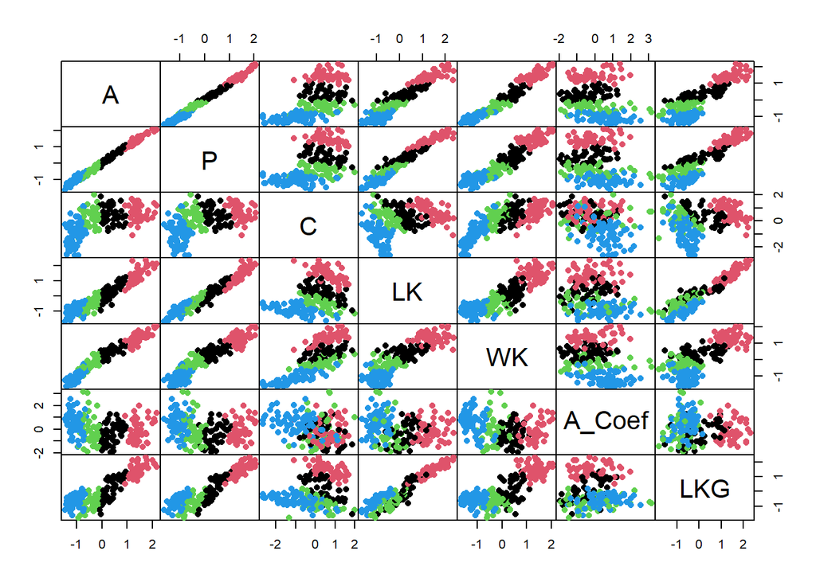

```r
pairs(df.scaled, gap=0, pch = 16, col = mod$classification) #insome plot the separations is good, in other situations the colors are overlapped
```

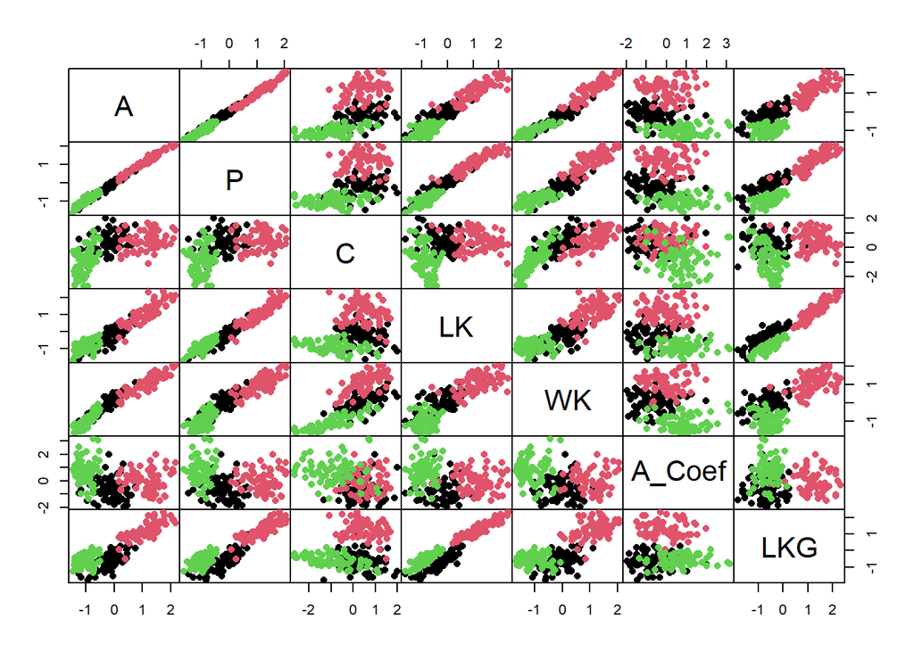

```r
pairs(df.scaled, gap=0, pch = 16, col=seed$target)
```

```r
seed$target[seed$target == 0 & mod$classification %in% c(1,3,4)] <- -1
table(seed$target, mod$classification)
```

```
##
##      1  2  3  4
##   1 29  0 38  3
##   2 21 49  0  0
##   3  0  0  7 63
```

```r
adjustedRandIndex(seed$target, mod$classification) #assume valuebetween -1 (disagreement) and 1 (great agreement)
```

```
## [1] 0.5795368
```

```r
classError(seed$target,mod$classification)
```

```
## $misclassified
##  [1]   1   2   5   7   9  10  11  16  18  19  23  24  25  26  32  35  36  37  38
## [20]  39  44  45  47  48  49  50  52  56  58  59  61  62  71  72  73  75  76  77
## [39]  80  81  96 101 108 123 125 133 134 135 136 137 138 139 140 142 143 196 197
## [58] 198 204 208
##
## $errorRate
## [1] 0.2857143
```

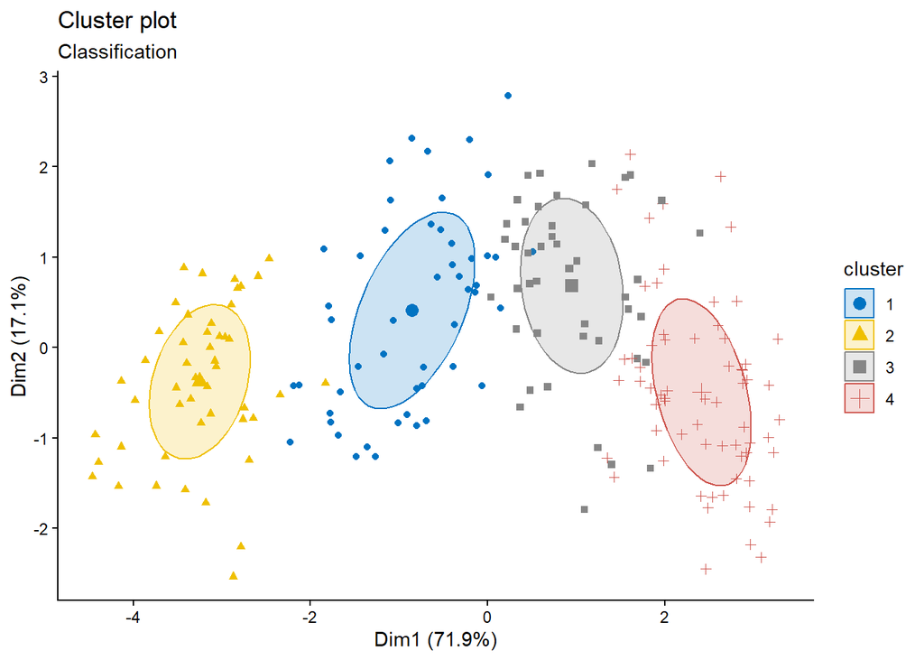

```r
fviz_mclust(mod, "classification", geom = "point", pointsize = 1.5
, palette = "jco") #remember that cluster are determined in the original space, so could be sovrapposition between cluster in PCA space
```